# 산학협엽과제 데이터 설명서

## 과제명 : 전기차 고전압 배터리의 주행상태 데이터를 활용한 충전용량 예측

### 차량 시계열 센서 신호를 활용하여 고전압 배터리 SOC 상태에 따른 주행가능거리(충전용량) 예측 모형 생성

### 1. 충전 용량 예측(주행거리 값 예측)

> > > - 시간(날짜) 별로 발생되는 SOC 상태 값에 대한 주행거리 데이터 생성
> > > - 날짜/주행거리/SOC 상태값의 변화량을 활용한 특정 주행거리 시점별 충전용량 예측

### 2. 충전용량(주행거리)와 연관 있는 주행 패턴 추출

> > > - 차속, YawRate, 종/횡가속도 를 활용한 주행 패턴 추출

## 분석 요건 설명

> > 1. 데이터 준비 및 사전 프로파일링
> >    - 시계열 데이터 셋 현황 파악 : 각 채널별 변수 통계값 추출
> >    - **데이터 설명서**
> >      - 데이터는 ";" 딜리미터로 되어있음
> >      - 시계열 데이터의 형태로 존재함
> > 2. 데이터 가공
> >    - 시계열 데이터 가공 : SOC상태, 주행가능거리, 시간별 값을 활용한 데이터 가공
> > 3. 분석 모형 생성
> >    - 시간의 텀으로 발생하는 동일한 SOC 충전용량일 때의 주행가능 거리를 활용한 주행가능 거리 예측
> >    - 시계열 예측 모형 활용
> >    - **배터리 성능 열화 인자 발굴**
> >      - 모터토크, 모터RPM, 차속, 브레이크 작동횟수 등
> > 4. 결과 평가
> >    - 주행거리(ODO)가 늘어남으로 인해 1만,5만,10만 KM 단위에서의 동일 SOC 상태의 누적주행 가능 거리 예측 모형 생성

### . 컬럼 테이블 정의서

| **컬럼** | **설명** |
| --- | --- |
| dnt | 날짜 |
| B_C | 배터리 전류 |
| B_V | 배터리 전압 |
| B_SOC | SOC |
| B_SOH | SOH |
| B_C_S | 충전상태 |
| ODO | 오도미터 |
| B_I | DC 버스 전류 |
| B_Max_V | 최대 배터리 셀 전압 |
| B_MAX_T | 퀵차져 온도 |
| B_MIN_V | 최소 배터리 셀 전압 |
| B_MIN_T | 최소 배터리 온도 |
| B_T_V | 배털 DC 버스 전압 |
| B_D_SOC | 표시 SOC |
| B_HPW | 히터 소비 에너지 |
| B_I_C | 배터리 인렛 온도 |
| B_P_C | PRA 온도 |
| B_SOC_DP | 배터리 SOC |
| B_SOC_P | 배터리 SOC |
| L_P_W | 로드 파워 |
| L_PM_W | LDC 입력 전원 모니터 |
| L_T | LDC 온도 |
| M_G_P_W | 누적 재생 에너지 |
| M_RPM | 모터 RPM |
| M_MET | 모터 토크 |
| M_P_W | 누적 모터 에너지 |
| M_M_RPM | 실제 모터 RPM |
| M_V_MET | 실제 모터 토크 |
| M_V_MT | 모터 온도 |
| M_KPH | 차속 KPH 설명 |
| M_KPHD | 차속 KPH |
| O_M_C | AC 입력 전류 |
| O_M_V | AC 입력 전압 |
| O_PE | OBC 출력 파워 |
| O_T | OBC 온도 |
| V_DA_K | 남은 주행거리 |
| V_D_K | 최대 남은 주행거리 |
| LAT_AC | 횡가속도 |
| LONG_AC | 종가속도 |
| NO | 번호 |
| SAS_Angle | SAS 각도 |
| SAS_Speed | SAS 속도 |
| YAW_RATE | YAW 비율 |
| course | 코스명 |
| master | 마스터 채널 정보 |

# Data Profliling

- 활용 변수 : 1. 주행가능거리, 2. 배터리 SOC, 3. 전류

[figure not shown]

```python
# Sample Data Loading
import pandas as pd
import matplotlib.pyplot as plt
%matplotlib inline
df = pd.read_csv('F:/001. AI Data(19)/20빅데이터분석양성과정/분석과제2-배터리예측/EV/201911.csv', sep=';')
```

```python
df.describe()
```

|  | BAT_SNSR_I | BAT_SNSR_V | BAT_SOC | BAT_SOH | CF_Bms_ChgSts | CF_Clu_Odometer | CR_Bms_BatI_A | CR_Bms_BatMaxCel_V | CR_Bms_BatMaxTemp_C | CR_Bms_BatMinCel_V | ... | CR_Vcu_DistEmptyAvn_km | CR_Vcu_DistEmpty_km_51 | LAT_ACCEL | LONG_ACCEL | NO | SAS_Angle | SAS_Speed | YAW_RATE | course | master |
| --- | --- | --- | --- | --- | --- | --- | --- | --- | --- | --- | --- | --- | --- | --- | --- | --- | --- | --- | --- | --- | --- |
| count | 2.461451e+06 | 2.461451e+06 | 2.461451e+06 | 2.461451e+06 | 2.455408e+06 | 2.461451e+06 | 2.455408e+06 | 2.455408e+06 | 2.455408e+06 | 2.455408e+06 | ... | 2.461451e+06 | 2.461451e+06 | 2.447266e+06 | 2.447266e+06 | 2.461451e+06 | 2.447266e+06 | 2.447266e+06 | 2.447266e+06 | 2461451.0 | 2.461451e+06 |
| mean | 2.854974e+00 | 1.401350e+01 | 9.558705e+01 | 9.715080e+01 | 6.489023e-02 | 2.925345e+05 | 4.986280e+00 | 3.907075e+00 | 2.708454e+01 | 3.902082e+00 | ... | 3.184577e+02 | 3.008229e+02 | -1.161747e-01 | -1.054988e-01 | 6.184395e+03 | 5.790399e+00 | 4.425683e+00 | -2.270685e+00 | 201911.0 | 3.497605e+03 |
| std | 5.926695e+00 | 6.508426e-01 | 2.873759e+00 | 2.340946e+00 | 2.463321e-01 | 4.254785e+03 | 5.981160e+01 | 2.114209e-01 | 7.165263e+00 | 2.137667e-01 | ... | 1.064722e+02 | 9.951499e+01 | 7.844522e-01 | 8.774042e-01 | 7.000055e+01 | 1.396784e+02 | 4.444082e+01 | 3.903148e+00 | 0.0 | 4.362976e+03 |
| min | -3.121620e+01 | 6.194994e+00 | 0.000000e+00 | 0.000000e+00 | 0.000000e+00 | 2.857418e+05 | -3.631992e+02 | 3.146153e+00 | 1.200000e+01 | 3.080000e+00 | ... | 0.000000e+00 | 0.000000e+00 | -1.023000e+01 | -1.023000e+01 | 6.056000e+03 | -4.531000e+02 | 0.000000e+00 | -4.095000e+01 | 201911.0 | 2.400085e+02 |
| 25% | 0.000000e+00 | 1.385559e+01 | 9.400000e+01 | 9.600000e+01 | 0.000000e+00 | 2.891449e+05 | 0.000000e+00 | 3.720000e+00 | 2.400000e+01 | 3.720000e+00 | ... | 2.460000e+02 | 2.320000e+02 | -2.300000e-01 | -3.400000e-01 | 6.125000e+03 | -4.087957e+00 | 0.000000e+00 | -2.390000e+00 | 201911.0 | 2.409360e+02 |
| 50% | 1.000000e+00 | 1.407000e+01 | 9.600000e+01 | 9.800000e+01 | 0.000000e+00 | 2.929418e+05 | 7.000000e-01 | 3.960000e+00 | 2.800000e+01 | 3.960000e+00 | ... | 3.400000e+02 | 3.250000e+02 | -1.557500e-01 | -1.200000e-01 | 6.194000e+03 | -1.127500e-01 | 0.000000e+00 | -2.310000e+00 | 201911.0 | 1.482646e+03 |
| 75% | 5.000000e+00 | 1.455800e+01 | 9.800000e+01 | 9.800000e+01 | 0.000000e+00 | 2.965644e+05 | 2.623230e+00 | 4.100000e+00 | 3.200000e+01 | 4.100000e+00 | ... | 4.160000e+02 | 3.820000e+02 | -2.155630e-02 | -1.000000e-02 | 6.246000e+03 | 4.400000e+00 | 0.000000e+00 | -2.240000e+00 | 201911.0 | 5.206139e+03 |
| max | 5.055028e+01 | 1.495975e+01 | 1.000000e+02 | 1.000000e+02 | 1.000000e+00 | 3.001413e+05 | 4.556014e+02 | 4.201625e+00 | 4.400000e+01 | 4.200000e+00 | ... | 4.640000e+02 | 4.480000e+02 | 1.024000e+01 | 1.024000e+01 | 6.305000e+03 | 3.276700e+03 | 1.020000e+03 | 4.096000e+01 | 201911.0 | 2.253293e+04 |

8 rows × 44 columns

```python
df.columns
```

```
Index(['dnt', 'BAT_SNSR_I', 'BAT_SNSR_V', 'BAT_SOC', 'BAT_SOH',
       'CF_Bms_ChgSts', 'CF_Clu_Odometer', 'CR_Bms_BatI_A',
       'CR_Bms_BatMaxCel_V', 'CR_Bms_BatMaxTemp_C', 'CR_Bms_BatMinCel_V',
       'CR_Bms_BatMinTemp_C', 'CR_Bms_BatTotV_V', 'CR_Bms_DisplaySoc',
       'CR_Bms_HeatPwrSum_Wh', 'CR_Bms_Inlet_C', 'CR_Bms_PRATemp_C',
       'CR_Bms_SocDec_Pc', 'CR_Bms_Soc_Pc', 'CR_LDC_LoadPwrSum',
       'CR_Ldc_PwrMon_W', 'CR_Ldc_Tmp', 'CR_Mcu_Gen_Power_wh',
       'CR_Mcu_MotActRotSpd_rpm', 'CR_Mcu_MotEstTq_Pc', 'CR_Mcu_Mot_Power_wh',
       'CR_Mcu_VCRM_MotActRotSpd_rpm', 'CR_Mcu_VCRM_MotEstTq_Pc',
       'CR_Mcu_VCRM_MotTemp_C', 'CR_Mcu_VehSpdDec_Kph', 'CR_Mcu_VehSpd_Kph',
       'CR_OBC_Mains_Cur', 'CR_OBC_Mains_Vol', 'CR_OBC_PwrEst', 'CR_OBC_TEMP',
       'CR_Vcu_DistEmptyAvn_km', 'CR_Vcu_DistEmpty_km_51', 'LAT_ACCEL',
       'LONG_ACCEL', 'NO', 'SAS_Angle', 'SAS_Speed', 'YAW_RATE', 'course',
       'master'],
      dtype='object')
```

```python
df[['dnt','CR_Bms_Soc_Pc','CR_Vcu_DistEmptyAvn_km','CR_Vcu_DistEmpty_km_51']]
```

|  | dnt | CR_Bms_Soc_Pc | CR_Vcu_DistEmptyAvn_km | CR_Vcu_DistEmpty_km_51 |
| --- | --- | --- | --- | --- |
| 0 | 2019-11-01 03:25:18 | 86.0 | 396.0 | 366 |
| 1 | 2019-11-01 03:25:19 | 86.0 | 396.0 | 366 |
| 2 | 2019-11-01 03:25:20 | 86.0 | 396.0 | 366 |
| 3 | 2019-11-01 03:25:21 | 86.0 | 396.0 | 366 |
| 4 | 2019-11-01 03:25:22 | 86.0 | 396.0 | 366 |
| 5 | 2019-11-01 03:25:23 | 86.0 | 396.0 | 366 |
| 6 | 2019-11-01 03:25:24 | 86.0 | 396.0 | 366 |
| 7 | 2019-11-01 03:25:25 | 86.0 | 396.0 | 366 |
| 8 | 2019-11-01 03:25:26 | 86.0 | 396.0 | 366 |
| 9 | 2019-11-01 03:25:27 | 86.0 | 396.0 | 366 |
| 10 | 2019-11-01 03:25:28 | 86.0 | 396.0 | 366 |
| 11 | 2019-11-01 03:25:29 | 86.0 | 396.0 | 366 |
| 12 | 2019-11-01 03:25:30 | 86.0 | 396.0 | 366 |
| 13 | 2019-11-01 03:25:31 | 86.0 | 396.0 | 366 |
| 14 | 2019-11-01 03:25:32 | 86.0 | 396.0 | 366 |
| 15 | 2019-11-01 03:25:33 | 86.0 | 396.0 | 366 |
| 16 | 2019-11-01 03:25:34 | 86.0 | 396.0 | 366 |
| 17 | 2019-11-01 03:25:35 | 86.0 | 396.0 | 366 |
| 18 | 2019-11-01 03:25:36 | 86.0 | 396.0 | 366 |
| 19 | 2019-11-01 03:25:37 | 86.0 | 396.0 | 366 |
| 20 | 2019-11-01 03:25:38 | 86.0 | 396.0 | 366 |
| 21 | 2019-11-01 03:25:39 | 86.0 | 396.0 | 366 |
| 22 | 2019-11-01 03:25:40 | 86.0 | 396.0 | 366 |
| 23 | 2019-11-01 03:25:41 | 86.0 | 396.0 | 366 |
| 24 | 2019-11-01 03:25:42 | 86.0 | 396.0 | 366 |
| 25 | 2019-11-01 03:25:43 | 86.0 | 396.0 | 366 |
| 26 | 2019-11-01 03:25:44 | 86.0 | 396.0 | 366 |
| 27 | 2019-11-01 03:25:45 | 86.0 | 396.0 | 366 |
| 28 | 2019-11-01 03:25:46 | 86.0 | 396.0 | 366 |
| 29 | 2019-11-01 03:25:47 | 86.0 | 396.0 | 366 |
| ... | ... | ... | ... | ... |
| 2461421 | 2019-11-29 15:08:59 | 56.0 | 218.0 | 222 |
| 2461422 | 2019-11-29 15:09:00 | 56.0 | 218.0 | 222 |
| 2461423 | 2019-11-29 15:09:01 | 56.0 | 218.0 | 222 |
| 2461424 | 2019-11-29 15:09:02 | 56.0 | 218.0 | 222 |
| 2461425 | 2019-11-29 15:09:03 | 56.0 | 218.0 | 222 |
| 2461426 | 2019-11-29 15:09:04 | 56.0 | 218.0 | 222 |
| 2461427 | 2019-11-29 15:09:05 | 56.0 | 218.0 | 222 |
| 2461428 | 2019-11-29 15:09:06 | 56.0 | 218.0 | 222 |
| 2461429 | 2019-11-29 15:09:07 | 56.0 | 218.0 | 222 |
| 2461430 | 2019-11-29 15:09:08 | 56.0 | 218.0 | 222 |
| 2461431 | 2019-11-29 15:09:09 | 56.0 | 218.0 | 222 |
| 2461432 | 2019-11-29 15:09:10 | 56.0 | 218.0 | 222 |
| 2461433 | 2019-11-29 15:09:11 | 56.0 | 218.0 | 222 |
| 2461434 | 2019-11-29 15:09:12 | 56.0 | 218.0 | 222 |
| 2461435 | 2019-11-29 15:09:13 | 56.0 | 218.0 | 222 |
| 2461436 | 2019-11-29 15:09:14 | 56.0 | 218.0 | 222 |
| 2461437 | 2019-11-29 15:09:15 | 56.0 | 218.0 | 222 |
| 2461438 | 2019-11-29 15:09:16 | 56.0 | 218.0 | 222 |
| 2461439 | 2019-11-29 15:09:17 | 56.0 | 218.0 | 222 |
| 2461440 | 2019-11-29 15:09:18 | 56.0 | 218.0 | 222 |
| 2461441 | 2019-11-29 15:09:19 | 56.0 | 218.0 | 222 |
| 2461442 | 2019-11-29 15:09:20 | 56.0 | 218.0 | 222 |
| 2461443 | 2019-11-29 15:09:21 | 56.0 | 218.0 | 222 |
| 2461444 | 2019-11-29 15:09:22 | 56.0 | 218.0 | 222 |
| 2461445 | 2019-11-29 15:09:23 | 56.0 | 218.0 | 222 |
| 2461446 | 2019-11-29 15:09:24 | 56.0 | 218.0 | 222 |
| 2461447 | 2019-11-29 15:09:25 | 56.0 | 218.0 | 222 |
| 2461448 | 2019-11-29 15:09:26 | 56.0 | 218.0 | 222 |
| 2461449 | 2019-11-29 15:09:27 | 56.0 | 218.0 | 222 |
| 2461450 | 2019-11-29 15:09:28 | 56.0 | 218.0 | 222 |

2461451 rows × 4 columns

```
array([<matplotlib.axes._subplots.AxesSubplot object at 0x000000001D093160>,
      dtype=object)
```

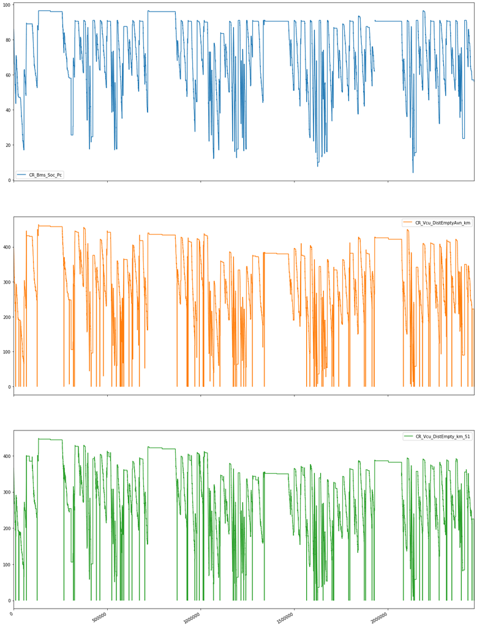

```python
df[['dnt','CR_Bms_Soc_Pc','CR_Vcu_DistEmptyAvn_km','CR_Vcu_DistEmpty_km_51']].plot(figsize=(20,30), subplots=True, label=True)
```

```python
df['CR_Bms_Soc_Pc'].value_counts()
```

```
90.500000    492042
96.000000    209529
91.000000     95853
96.500000     74613
89.000000     41441
              ...
95.533000         1
60.454227         1
70.470500         1
77.812500         1
25.148000         1
Name: CR_Bms_Soc_Pc, Length: 2012, dtype: int64
```

```python
a.to_csv('SOC_PC.csv')
```

[output not shown]